# Assignment 1

Failure Mode and Effects Analysis

SYSEN 5300/6300

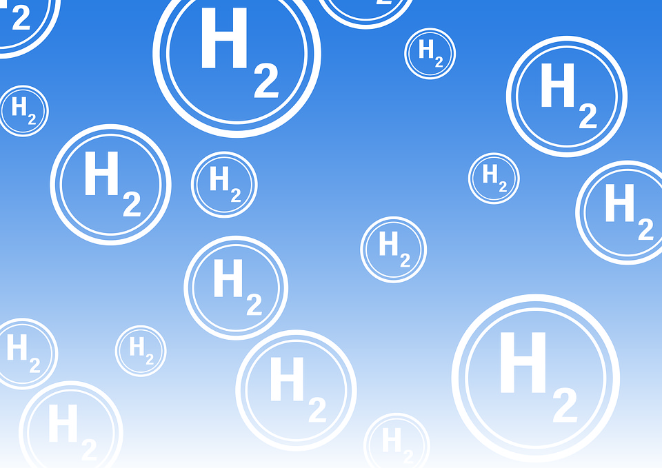

# 0. Prompt

Design an FMEA for a “hydrogen power park.” an energy generation and dispensing site that serves as a combination of filling station for hydrogen-powered vehicles and fuel cell powered clean electricity generator.

## 0.1 Formatting

- **Form a group of 3-5 students**. Working together and discussing the final shape of the FMEA is essential in real world FMEA.
- Please present your FMEA in a **1-2 page group report** (single spaced, 12 font, Times New Roman, **.docx** or **.pdf** file, submitted on Canvas.) Figures or Tables do not count towards page limit. Please include any files you use. If you have questions, **email us pronto!**

## 0.2 Requirements

Your FMEA must include the following:

1. **Construct a cause-and-effect diagram** (i.e., fishbone diagram) for a potential overall system failure of the hydrogen power park.
2. List **at least 10 failure modes** for the design.
3. **Calculate the RPN value** for each failure mode.
4. Identify **maximum acceptable value for RPN**, and show *which* failure modes exceed that value.
5. For the 3 failure modes with the greatest RPN, **construct fishbone diagrams** for *each* of the three failure modes. Suggest modifications to reduce RPN and recalculate the value. Revise the top 3 modes, regardless of whether their RPN exceeds the maximum allowable value.

Please review the **links** below as part of this assignment:

1. [**Plan View of Hydrogen Power Park Site**](https://drive.google.com/uc?export=download&id=1Htbh3xZhk5lyUwRpOqzA47rHJPOvZ4bq)
2. [**Schematic for the hydrogen dispensing and clean electricity generation processes**](https://drive.google.com/uc?export=download&id=1-uBziJziMGMBWJ7FMLhNpqHKw-qY0pzA)
3. [**Design FMEA template**](https://docs.google.com/spreadsheets/d/12WQyQd0XiSmV_Cr07zxg0byX-OeGa-4ALYUT9nheAOI/view?usp=sharing#gid=1197286946) and [**Fishbone diagram template**](https://docs.google.com/spreadsheets/d/12WQyQd0XiSmV_Cr07zxg0byX-OeGa-4ALYUT9nheAOI/view?usp=sharing#gid=349755440) on Google Sheets.

You can consider using our templates and/or make your diagrams in `mermaid` from our `R` tutorial. (Ignore any columns/features not relevant to your case.)

[figure not shown]

[figure not shown]

Figure 1: Templates

# 1. Background

## 1.1 Introduction

There has been much discussion in the engineering community as well as the popular press recently about using hydrogen as a fuel for highway transportation. This is especially relevant once petroleum supplies decline, as they are expected to do sometime in the next 5 to 10 years. Along with large-scale hydrogen generation facilities (e.g. solar power stations in the southwestern US that electrolyze large quantities of water to make hydrogen) and the ability to store and combust hydrogen safely and efficiently on board the vehicles, the hydrogen dispensing station is another key component in this technological system that must work correctly in order for the technology to succeed. The hydrogen power park is therefore the replacement for today’s gas station. The term “power park” indicates that the facility is not only a filling station but also a facility where electricity can be generated without pollution for distribution on the electric grid.

## 1.2 Plan View

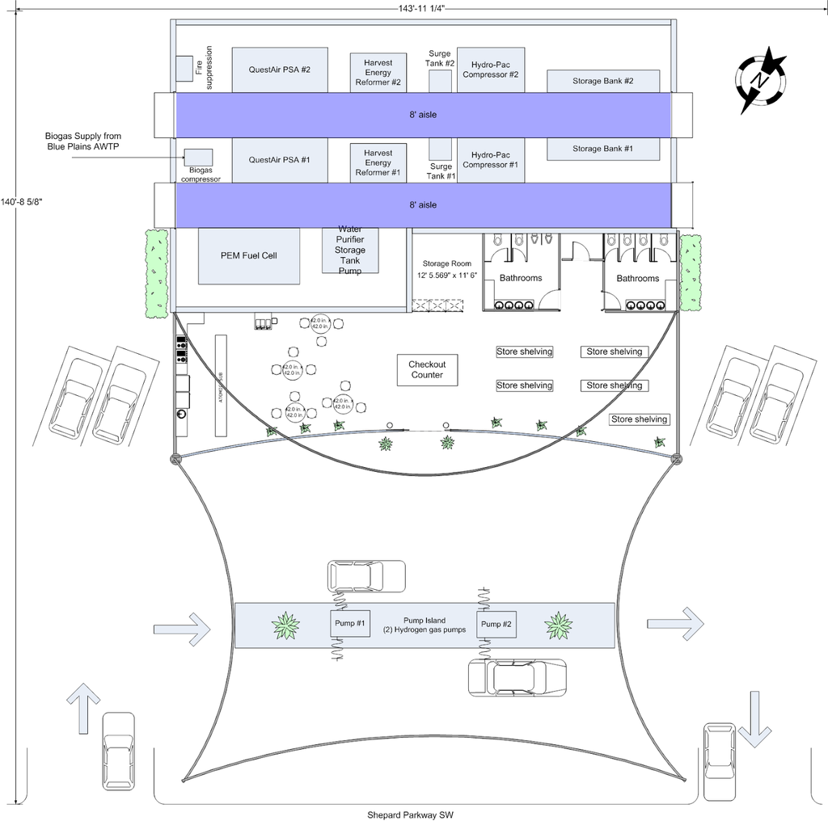

Figure 2: Plan View

**Figure 2** shows a plan view of the particular power park design to be analyzed. The site is approximately the size of an average gasoline filling station, and can roughly be divided into three parts: (1) area for dispensing hydrogen to vehicles, (2) retail facility (including a convenience store and restrooms), and (3) mechanical room for generating hydrogen and clean electricity.

The design under study is located next to a sewage treatment plant. So, the raw material for both the hydrogen and for use in the fuel cell is biogas from the plant. The biogas is scrubbed before it leaves the treatment plant, so it arrives in the power park at the same level of quality asnatural gas that is sold on the gas grid, and can be used in either a methane steam reformer (device for converting methane to hydrogen) or fuel cell without further purification. The benefit of using biogas from the treatment plant is to reduce total solid waste output (since digesting the waste from the plant and converting the gas from this process into hydrogen reduces its total volume) and also to provide an energy source for hydrogen that is not based on fossil fuels and does not contribute to increased CO2 in the atmosphere.

## 1.3 Schematics

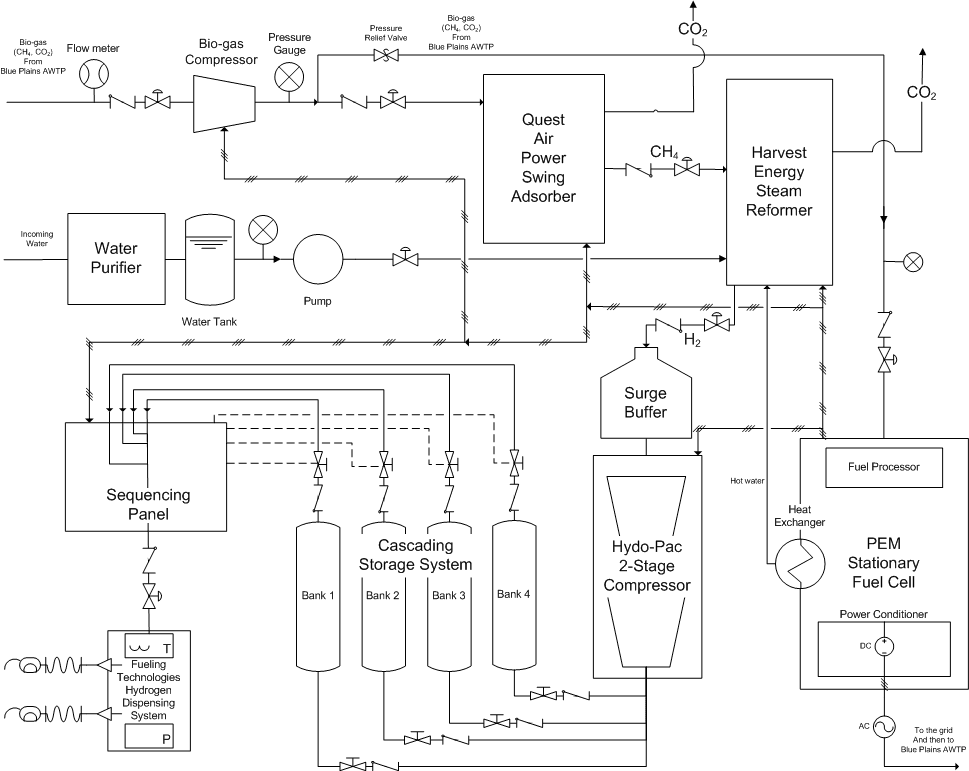

Figure 3: Schematics

**Figure 3** shows the schematic for the hydrogen dispensing and clean electricity generation processes. Solid lines are physical flows of gases within the system, and lines with hash-marks are lines of control/communications. The steps in the process are as follows:

1. The gas arrives from the waste treatment plant and is compressed for further distribution in the power park.
2. Thereafter, the stream is divided between gas entering the swing adsorber, where any excess CO2in the gas is removed, and gas that passes directly to the stationary fuel cell.
3. The gas in the fuel cell is converted to electricity, as controlled by the fuel processor; heat from fuel cell process is also transferred to a hot water stream in a heat exchanger,and the hot water is sent to the steam reformer.
4. The steam reformer takes in a stream of gas and purified water from the outside, to first boil the water and then react with the methane to produce hydrogen, with CO2as a byproduct.
5. Hydrogen leaving the steam reformer and passes through a surge buffer and then into a compressor, which compresses the hydrogen and distributes it into a cascading storage system.
6. Each of the 4 tanks in the cascade system has a maximum pressure of 6500 psi.

The purpose of the cascading system is to allow power park tanks at partial pressure to charge the vehicle to up to their maximum available pressure. For example, if one of the power park tanks is at 1500 psi, it will fill the vehicle tank until the vehicle is close to 1500 psi, e.g. 1300 psi. Thereafter another power park tank that happens to be at a higher pressure will take over, and this process is repeated so that the vehicle tank is incrementally filled until it reaches its design pressure, which is 5000 psi in this case. The purpose of the cascading system is to reduce energy consumption in compressing hydrogen, since each power park tank is not required to be at the full 6500 psi in order to contribute to the dispensing process.

All electricity consumed in the power park, including electricity for control of the hydrogen production devices and for operating the retail facility, is produced in the fuel cell and distributed around the power park at either 220V or 110V. Average power consumption is estimated at 100 kW. The fuel cell is rated at 200 kW, so the remaining average of 100 kW is fed into the adjacent grid. The exported electricity leaves the site at 220V, and transforming it to a higher voltage is outside the scope of the assignment.

## 1.4 Risks at the Power Park

1. Biogas fire risk: rupture of gas lines within the facility and/or exposure to flame may lead to a fire.
2. Hydrogen fire risk: if exposed to a flame, hydrogen burns in air without color, and is therefore hard to detect. It is also sensitive to exposure to sparks, being approximately 10 times more likely to ignite from a spark than a gasoline-air mixture.
3. High-pressure hydrogen tank or line rupture risk: rupture of hydrogen vessels pressurized up to 6500 psi can lead to an explosion.
4. Electric shock risk: fuel cell and other power consuming equipment pose a hazard of electric shock; 200 kw of output at 220V produces a current of 909 Amps, or roughly 9 times the maximum current flowing into a typical house or other residence in the USA (with 100 Amp service).

Please study in depth the potential for these 4 hazards within power park components.

- Assume that components have been engineered to withstand maximum loads, taking into account appropriate safety factors, e.g. the connection between the cascading tank system and the dispenser can withstand 6500 psi.
- Assume you are receiving the design in basic form pre-installation of any sensors, alarm systems, impact-resistant shielding, etc. (This allows you to explore a range of safety solutions.)
- Failure modes may also lead to loss of productivity, inconvenience to the customer if the facility works poorly or shuts down entirely, etc.

## 1.5 Scope of Evaluation

- Include all failure modes that can occur on-site, including failure modes involving vehicles that enter the site.
- Scope does not include failure modes that happen off-site but are directly or indirectly caused by the function of the power park.

# 2. Measurement

## 2.1 Interpretation of Severity/Occurrence/Detection:

- Many different scales can be used for FMEA. Your reading material uses a scale of 1 to 10 for evaluating factors in the RPN, the power park evaluation uses a 1 to 5 scale instead. The best possible RPN is 1, and the worst possible is 125.
- For initial FMEA, give the name of the failure for the 10 failures chosen, and give the S/O/D scores and RPN value.
- No mathematical derivation necessary (but assign sensible values). For example, extremely unlikely failures, like a valve failing when under warrantee for 10 years, should not receive an Occurrence score of 5.

## 2.2 Cause and Effect

For top 3 failures, state the cause and effect of each. You do not need to provide a mathematical derivation of the value. (See sections *Severity*, *Occurrence*, and *Detection* below!)

## 2.3 Severity

Table 1: Severity Ratings

| score | description |
| --- | --- |
| 1 | Machine breakdown or degraded performance |
| 2 | Complete or partial system failure, or breakdown leading to major nuisance e.g. extreme noise, but no injury, fire or leakage |
| 3 | Mild injuries, small fires, minor leakages of gas, hydrogen, etc. |
| 4 | Severe injury, major component damage due to fire, rupture, etc. |
| 5 | Loss of human life, or total or near-total loss of the facility |

## 2.4 Occurrence

Table 2: Occurrence Ratings

| score | description |
| --- | --- |
| 1 | Once in 50 years |
| 2 | Once in 10 years |
| 3 | Once in 5 years |
| 4 | Once per year |
| 5 | Once per month |

- *Note*: Less severe failures (1-2) involve disruptions, but no serious events such as injuries, fires, or leakages, which are more severe types of leakages (3-5).

## 2.5 Detection

Table 3: Detection Ratings

| score | description |
| --- | --- |
| 1 | Easily detected in middle of normal activities,<br>e.g. operator hears an unusual noise coming from failed component and detects failure |
| 2 | Detected with regular inspections that are easy to carry outby ordinary on-site staff |
| 3 | Visit by manufacturer’s representative with specialized technical expertise required to detect, but major shutdown of component not required |
| 4 | Extensive shutdown of component required to detect failure |
| 5 | No detection possiblesince failure is triggered instantaneously |

- *Note*: Detection Scoring is based on the ability to make the necessary detection in advance to prevent the failure. For some failures, no detection is possible, so these receive a score of `5`. (Examples include human errors, like driving vehicles to the wrong location.)